# CNN Avec peu de données

#### Chargement du code

```python
import numpy as np
from matplotlib import pyplot as plt
import tensorflow as tf

np.random.seed(123)  # for reproducibility
tf.random.set_seed(123)

%load_ext autoreload
%autoreload 2
```

```python
from TP3_utils import load_dataset

DATA_PATH = 'Data'
CATEGORIES = ["accordion", "anchor", "barrel", "binocular"]

(X_train, Y_train), (X_test, Y_test), num_classes = load_dataset(DATA_PATH, CATEGORIES)
data_shape = X_train[0].shape

print("Training data shape:", data_shape)
print("Training labels shape:", Y_train.shape)
print("Test data shape:", X_test.shape)
print("Test labels shape:", Y_test.shape)
print("Number of classes:", num_classes)
```

```
Finished loading 177 images from 4 categories.
Train/Test split: 123 / 54
Training data shape: (224, 224, 3)
Training labels shape: (123, 4)
Test data shape: (54, 224, 224, 3)
Test labels shape: (54, 4)
Number of classes: 4
```

[output not shown]

Les images d'entrées sont redimensionnées à 224x224, et en couleurs (3 canaux pour RGB).  
Il y a 4 classes en sortie, et la répartition est de 70% / 30% soit 123 examples d'entrainement et 54 de test sur les 177 chargés.

```
Model: "functional_1"
```

```
┏━━━━━━━━━━━━━━━━━━━━━━━━━━━━━━━━━┳━━━━━━━━━━━━━━━━━━━━━━━━┳━━━━━━━━━━━━━━━┓
┃ Layer (type)                    ┃ Output Shape           ┃       Param # ┃
┡━━━━━━━━━━━━━━━━━━━━━━━━━━━━━━━━━╇━━━━━━━━━━━━━━━━━━━━━━━━╇━━━━━━━━━━━━━━━┩
│ input_layer (InputLayer)        │ (None, 224, 224, 3)    │             0 │
├─────────────────────────────────┼────────────────────────┼───────────────┤
│ sequential (Sequential)         │ (None, 224, 224, 3)    │             0 │
├─────────────────────────────────┼────────────────────────┼───────────────┤
│ conv2d (Conv2D)                 │ (None, 224, 224, 16)   │           448 │
├─────────────────────────────────┼────────────────────────┼───────────────┤
│ max_pooling2d (MaxPooling2D)    │ (None, 112, 112, 16)   │             0 │
├─────────────────────────────────┼────────────────────────┼───────────────┤
│ conv2d_1 (Conv2D)               │ (None, 112, 112, 32)   │         4,640 │
├─────────────────────────────────┼────────────────────────┼───────────────┤
│ conv2d_2 (Conv2D)               │ (None, 112, 112, 32)   │         9,248 │
├─────────────────────────────────┼────────────────────────┼───────────────┤
│ max_pooling2d_1 (MaxPooling2D)  │ (None, 56, 56, 32)     │             0 │
├─────────────────────────────────┼────────────────────────┼───────────────┤
│ dropout (Dropout)               │ (None, 56, 56, 32)     │             0 │
├─────────────────────────────────┼────────────────────────┼───────────────┤
│ conv2d_3 (Conv2D)               │ (None, 56, 56, 64)     │        18,496 │
├─────────────────────────────────┼────────────────────────┼───────────────┤
│ conv2d_4 (Conv2D)               │ (None, 56, 56, 64)     │        36,928 │
├─────────────────────────────────┼────────────────────────┼───────────────┤
│ dropout_1 (Dropout)             │ (None, 56, 56, 64)     │             0 │
├─────────────────────────────────┼────────────────────────┼───────────────┤
│ flatten (Flatten)               │ (None, 200704)         │             0 │
├─────────────────────────────────┼────────────────────────┼───────────────┤
│ dense (Dense)                   │ (None, 100)            │    20,070,500 │
├─────────────────────────────────┼────────────────────────┼───────────────┤
│ dropout_2 (Dropout)             │ (None, 100)            │             0 │
├─────────────────────────────────┼────────────────────────┼───────────────┤
│ dense_1 (Dense)                 │ (None, 4)              │           404 │
└─────────────────────────────────┴────────────────────────┴───────────────┘
```

```
 Total params: 20,140,664 (76.83 MB)
```

```
 Trainable params: 20,140,664 (76.83 MB)
```

```
 Non-trainable params: 0 (0.00 B)
```

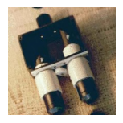

```
4/4 ━━━━━━━━━━━━━━━━━━━━ 3s 497ms/step - accuracy: 0.3089 - loss: 1.4556 - val_accuracy: 0.4815 - val_loss: 1.3045 - learning_rate: 1.0000e-04
4/4 ━━━━━━━━━━━━━━━━━━━━ 2s 445ms/step - accuracy: 0.3415 - loss: 1.3691 - val_accuracy: 0.6667 - val_loss: 1.1482 - learning_rate: 1.0000e-04
4/4 ━━━━━━━━━━━━━━━━━━━━ 2s 432ms/step - accuracy: 0.4309 - loss: 1.2772 - val_accuracy: 0.6667 - val_loss: 1.0795 - learning_rate: 1.0000e-04
4/4 ━━━━━━━━━━━━━━━━━━━━ 2s 427ms/step - accuracy: 0.4634 - loss: 1.2088 - val_accuracy: 0.7593 - val_loss: 0.9737 - learning_rate: 1.0000e-04
4/4 ━━━━━━━━━━━━━━━━━━━━ 2s 426ms/step - accuracy: 0.5041 - loss: 1.1355 - val_accuracy: 0.7778 - val_loss: 0.8628 - learning_rate: 1.0000e-04
4/4 ━━━━━━━━━━━━━━━━━━━━ 2s 427ms/step - accuracy: 0.5854 - loss: 1.0419 - val_accuracy: 0.7222 - val_loss: 0.7416 - learning_rate: 1.0000e-04
4/4 ━━━━━━━━━━━━━━━━━━━━ 2s 428ms/step - accuracy: 0.6423 - loss: 1.0069 - val_accuracy: 0.7778 - val_loss: 0.6771 - learning_rate: 1.0000e-04
4/4 ━━━━━━━━━━━━━━━━━━━━ 2s 429ms/step - accuracy: 0.6179 - loss: 0.9297 - val_accuracy: 0.7407 - val_loss: 0.6265 - learning_rate: 1.0000e-04
4/4 ━━━━━━━━━━━━━━━━━━━━ 2s 426ms/step - accuracy: 0.6179 - loss: 0.9272 - val_accuracy: 0.7963 - val_loss: 0.6031 - learning_rate: 1.0000e-04
4/4 ━━━━━━━━━━━━━━━━━━━━ 2s 426ms/step - accuracy: 0.6911 - loss: 0.8128 - val_accuracy: 0.7222 - val_loss: 0.5975 - learning_rate: 1.0000e-04
4/4 ━━━━━━━━━━━━━━━━━━━━ 2s 426ms/step - accuracy: 0.6504 - loss: 0.7754 - val_accuracy: 0.7593 - val_loss: 0.5500 - learning_rate: 1.0000e-04
4/4 ━━━━━━━━━━━━━━━━━━━━ 2s 438ms/step - accuracy: 0.6585 - loss: 0.7587 - val_accuracy: 0.7407 - val_loss: 0.6055 - learning_rate: 1.0000e-04
4/4 ━━━━━━━━━━━━━━━━━━━━ 2s 429ms/step - accuracy: 0.6504 - loss: 0.7779 - val_accuracy: 0.7593 - val_loss: 0.5290 - learning_rate: 1.0000e-04
4/4 ━━━━━━━━━━━━━━━━━━━━ 2s 438ms/step - accuracy: 0.6992 - loss: 0.6915 - val_accuracy: 0.7407 - val_loss: 0.5553 - learning_rate: 1.0000e-04
4/4 ━━━━━━━━━━━━━━━━━━━━ 0s 370ms/step - accuracy: 0.6880 - loss: 0.7282
Epoch 15: ReduceLROnPlateau reducing learning rate to 7.499999810534064e-05.
4/4 ━━━━━━━━━━━━━━━━━━━━ 2s 428ms/step - accuracy: 0.7154 - loss: 0.6690 - val_accuracy: 0.7963 - val_loss: 0.5338 - learning_rate: 1.0000e-04
4/4 ━━━━━━━━━━━━━━━━━━━━ 2s 428ms/step - accuracy: 0.7154 - loss: 0.6758 - val_accuracy: 0.7963 - val_loss: 0.5221 - learning_rate: 7.5000e-05
4/4 ━━━━━━━━━━━━━━━━━━━━ 2s 427ms/step - accuracy: 0.7805 - loss: 0.6097 - val_accuracy: 0.7778 - val_loss: 0.5461 - learning_rate: 7.5000e-05
4/4 ━━━━━━━━━━━━━━━━━━━━ 2s 429ms/step - accuracy: 0.7480 - loss: 0.6374 - val_accuracy: 0.7778 - val_loss: 0.4941 - learning_rate: 7.5000e-05
4/4 ━━━━━━━━━━━━━━━━━━━━ 2s 426ms/step - accuracy: 0.7724 - loss: 0.5386 - val_accuracy: 0.8148 - val_loss: 0.5046 - learning_rate: 7.5000e-05
4/4 ━━━━━━━━━━━━━━━━━━━━ 0s 372ms/step - accuracy: 0.7925 - loss: 0.5780
Epoch 20: ReduceLROnPlateau reducing learning rate to 5.6249997214763425e-05.
4/4 ━━━━━━━━━━━━━━━━━━━━ 2s 430ms/step - accuracy: 0.8211 - loss: 0.5295 - val_accuracy: 0.7778 - val_loss: 0.5220 - learning_rate: 7.5000e-05
4/4 ━━━━━━━━━━━━━━━━━━━━ 2s 427ms/step - accuracy: 0.8130 - loss: 0.4985 - val_accuracy: 0.8333 - val_loss: 0.4722 - learning_rate: 5.6250e-05
4/4 ━━━━━━━━━━━━━━━━━━━━ 2s 427ms/step - accuracy: 0.8049 - loss: 0.5010 - val_accuracy: 0.7963 - val_loss: 0.4760 - learning_rate: 5.6250e-05
4/4 ━━━━━━━━━━━━━━━━━━━━ 0s 379ms/step - accuracy: 0.8212 - loss: 0.4520
Epoch 23: ReduceLROnPlateau reducing learning rate to 4.218749927531462e-05.
4/4 ━━━━━━━━━━━━━━━━━━━━ 2s 437ms/step - accuracy: 0.8211 - loss: 0.4596 - val_accuracy: 0.7593 - val_loss: 0.5322 - learning_rate: 5.6250e-05
4/4 ━━━━━━━━━━━━━━━━━━━━ 2s 431ms/step - accuracy: 0.8130 - loss: 0.4697 - val_accuracy: 0.8333 - val_loss: 0.4646 - learning_rate: 4.2188e-05
4/4 ━━━━━━━━━━━━━━━━━━━━ 2s 426ms/step - accuracy: 0.8618 - loss: 0.4183 - val_accuracy: 0.8333 - val_loss: 0.4563 - learning_rate: 4.2188e-05
4/4 ━━━━━━━━━━━━━━━━━━━━ 2s 428ms/step - accuracy: 0.8374 - loss: 0.4422 - val_accuracy: 0.8148 - val_loss: 0.4702 - learning_rate: 4.2188e-05
4/4 ━━━━━━━━━━━━━━━━━━━━ 0s 370ms/step - accuracy: 0.8219 - loss: 0.3739
Epoch 27: ReduceLROnPlateau reducing learning rate to 3.164062582072802e-05.
4/4 ━━━━━━━━━━━━━━━━━━━━ 2s 428ms/step - accuracy: 0.8293 - loss: 0.4005 - val_accuracy: 0.7593 - val_loss: 0.4711 - learning_rate: 4.2188e-05
4/4 ━━━━━━━━━━━━━━━━━━━━ 2s 428ms/step - accuracy: 0.8455 - loss: 0.4143 - val_accuracy: 0.8148 - val_loss: 0.4388 - learning_rate: 3.1641e-05
4/4 ━━━━━━━━━━━━━━━━━━━━ 2s 431ms/step - accuracy: 0.8618 - loss: 0.3893 - val_accuracy: 0.8519 - val_loss: 0.4269 - learning_rate: 3.1641e-05
4/4 ━━━━━━━━━━━━━━━━━━━━ 2s 426ms/step - accuracy: 0.8537 - loss: 0.3806 - val_accuracy: 0.7963 - val_loss: 0.4611 - learning_rate: 3.1641e-05
4/4 ━━━━━━━━━━━━━━━━━━━━ 0s 369ms/step - accuracy: 0.8274 - loss: 0.3692
Epoch 31: ReduceLROnPlateau reducing learning rate to 2.3730469365546014e-05.
```

[output cut: 15 more lines]

```
Epoch 39: ReduceLROnPlateau reducing learning rate to 7.508469025196973e-06.
4/4 ━━━━━━━━━━━━━━━━━━━━ 2s 429ms/step - accuracy: 0.8862 - loss: 0.3390 - val_accuracy: 0.7407 - val_loss: 0.4494 - learning_rate: 1.0011e-05
4/4 ━━━━━━━━━━━━━━━━━━━━ 2s 429ms/step - accuracy: 0.8618 - loss: 0.3956 - val_accuracy: 0.7593 - val_loss: 0.4502 - learning_rate: 7.5085e-06
4/4 ━━━━━━━━━━━━━━━━━━━━ 0s 370ms/step - accuracy: 0.8713 - loss: 0.3323
Epoch 41: ReduceLROnPlateau reducing learning rate to 5.63135176889773e-06.
4/4 ━━━━━━━━━━━━━━━━━━━━ 2s 428ms/step - accuracy: 0.8862 - loss: 0.3132 - val_accuracy: 0.7593 - val_loss: 0.4542 - learning_rate: 7.5085e-06
4/4 ━━━━━━━━━━━━━━━━━━━━ 2s 428ms/step - accuracy: 0.9106 - loss: 0.2840 - val_accuracy: 0.7593 - val_loss: 0.4480 - learning_rate: 5.6314e-06
4/4 ━━━━━━━━━━━━━━━━━━━━ 0s 370ms/step - accuracy: 0.8111 - loss: 0.4033
Epoch 43: ReduceLROnPlateau reducing learning rate to 4.223513997203554e-06.
4/4 ━━━━━━━━━━━━━━━━━━━━ 2s 438ms/step - accuracy: 0.8537 - loss: 0.3581 - val_accuracy: 0.7593 - val_loss: 0.4434 - learning_rate: 5.6314e-06
4/4 ━━━━━━━━━━━━━━━━━━━━ 2s 430ms/step - accuracy: 0.8780 - loss: 0.3624 - val_accuracy: 0.7963 - val_loss: 0.4374 - learning_rate: 4.2235e-06
Epoch 44: early stopping
Restoring model weights from the end of the best epoch: 29.
2/2 ━━━━━━━━━━━━━━━━━━━━ 0s 73ms/step - accuracy: 0.8519 - loss: 0.4269
Test loss: 0.42687469720840454, Test accuracy: 0.8518518805503845
```

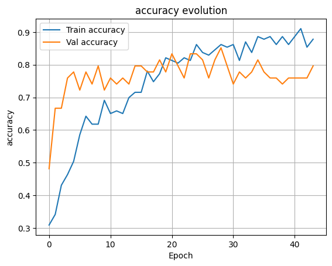

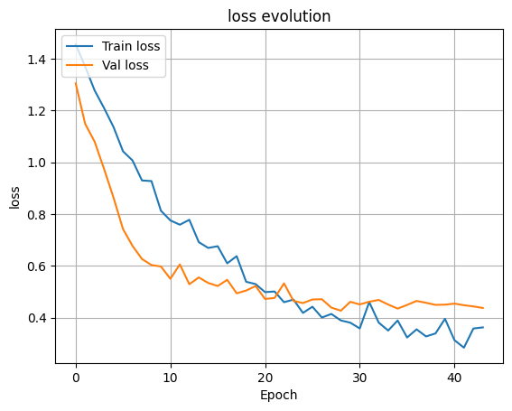

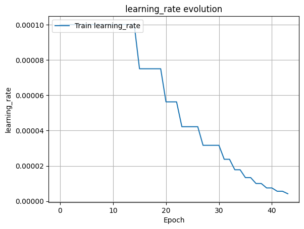

```
2/2 ━━━━━━━━━━━━━━━━━━━━ 0s 101ms/step
```

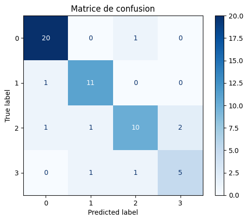

```
Classification report:
              precision    recall  f1-score   support

           0       0.91      0.95      0.93        21
           1       0.85      0.92      0.88        12
           2       0.83      0.71      0.77        14
           3       0.71      0.71      0.71         7

    accuracy                           0.85        54
   macro avg       0.83      0.82      0.82        54
weighted avg       0.85      0.85      0.85        54

Temps d'entraînement : 75.47 secondes
```

```python
import time
import tensorflow as tf
from tensorflow import keras
from keras.optimizers import Adam
from TP3_utils import CNN, affiche, eval_classif, data_augmentation
from keras.callbacks import ReduceLROnPlateau, EarlyStopping

lr_scheduler = ReduceLROnPlateau(monitor='val_loss', factor=0.75, patience=2, min_lr=1e-6, verbose=1)
earlStop = EarlyStopping(monitor='val_loss', min_delta=1e-4, patience=15, restore_best_weights=True, verbose = 1)

lr=1e-4
batch_size=32
epochs=64
ad= Adam(learning_rate=lr)

model = CNN(data_shape)
model.summary()

plt.figure(figsize=(10, 4))
for i in range(5):
    augmented_img = data_augmentation(tf.expand_dims(X_train[0], 0))
    plt.subplot(1, 5, i+1)
    plt.imshow(augmented_img[0])
    plt.axis("off")
    plt.show()

model.compile(
    loss='categorical_crossentropy',
    optimizer=ad,
    metrics=['accuracy']
)

tps1 = time.time()
history =model.fit(
    X_train,
    Y_train,
    batch_size=batch_size,
    epochs=epochs,
    verbose=1,
    validation_data=(X_test, Y_test),
    callbacks=[earlStop, lr_scheduler]
)
tps2 = time.time()

# Evaluation
loss, accuracy = model.evaluate(X_test, Y_test)
print(f'Test loss: {loss}, Test accuracy: {accuracy}')

affiche(history)
preds = model.predict(X_test)
eval_classif(Y_test, preds)
print("Temps d'entraînement : {:.2f} secondes".format(tps2 - tps1))
```

Le modèle initial à **20,090,296** paramètres entrainable. Après un entrainement de **19.32s**, le modèle atteint **loss=0.8; accuracy=66.66%**

Pour définir la structure du modèle, je fixe:

- lr=1e-4
- batch_size=16
- epochs=16
- optimizer=Adam(lr)
- MLP finale: Dense(100)

Puis, je procède de la façon suivante:

| itération | nb étages | taille des filtres | nb params | tps d'entrainement | loss | accuracy |
| --- | --- | --- | --- | --- | --- | --- |
| 1 | 2 | 16-32 | 40,146,392 | 23.37s | 0.7255 | 72.22% |
| 2 | 3 | 16-32-64 | 20,094,488 | 19.03s | 0.5276 | 77.77% |
| 3 | 4 | 16-32-64-128 | 10,133,144 | 18.83s | 0.8526 | 72.22% |
| 4 | 5 | 16-32-64-128-256 | 5,410,712 | 20.09s | 0.9057 | 70.37% |
| 5 | 3 | 32-64-128 | 40,234,552 | 47.86s | 0.8762 | 72.22% |
| 6 | 4 | 32-64-128-256 | 20,459,320 | 44.29s | 0.9546 | 75.92% |
| 7 | 5 | 32-64-128-256-512 | 11,604,280 | 51.48s | 0.7749 | 74.07% |
| 8 | 2 | 8-16 | 20,072,296 | 13.89s | 0.7267 | 66.66% |
| 9 | 3 | 8-16-32 | 10,041,736 | 12.12s | 0.7994 | 68.51% |

Le meilleur compromis semble alors être d'utiliser 3 étages, avec respectivement 16, 32 et 64 filtres. Pour enrichir le réseau, on peut maintenant essayer d'augmenter le nombre de couches par étages.

| itération | nb couches/étage | nb params | tps d'entrainement (total) | loss | best val_accuracy |
| --- | --- | --- | --- | --- | --- |
| 0 | 1-1-1 | 20,094,488 | 19.03s | 0.5276 | 77.77% |
| 1 | 2-1-1 | 20,096,808 | 28.84s | 0.8320 | 75.92% |
| 2 | 1-2-1 | 20,103,736 | 25.42s | 0.9896 | 72.22% |
| 3 | 1-1-2 | 20,131,416 | 23.72s | 0.9335 | 64.81% |
| 4 | 2-2-1 | 20,106,056 | 34.36s | 0.5813 | 74.07% |
| 5 | 2-1-2 | 20,133,736 | 34.46s | 0.6585 | 72.22% |
| 6 | 1-2-2 | 20,140,664 | 31.39s | 0.7302 | 79.62% |
| 7 | 2-2-2 | 20,142,984 | 40.51s | 0.7089 | 75.92% |

Bien que cette fois, l'impact est moins clair, la configuration qui semble la meilleure est 1-2-2 (bien que 79% semble avoir été un outlier, cette configuration donne de façon plutôt consistante >73% ce qui n'est pas le cas des autres). Ce que j'utiliserai par la suite. Cependant on remarque un fort overfitting. Pour palier cela, nous ajouterons du dropout pour les différentes layers, puis de la data augmentation.

La transformation qui me semble la plus efficace ici est une rotation légère. Aussi, avec data augmentation et dropout, l'entrainement était très instable, alors j'ai augmenté le batch_size. Malgrès tout, le modèle était très sensible et je n'ai pas pu mettre beaucoup de dropout, surtout sur les couches hautes. En m'aidant d'early stopping et d'un lr scheduler, j'ai atteint au mieux ces résultats:

```
Classification report:
              precision    recall  f1-score   support

           0       0.91      0.95      0.93        21
           1       0.85      0.92      0.88        12
           2       0.83      0.71      0.77        14
           3       0.71      0.71      0.71         7

    accuracy                           0.85        54
   macro avg       0.83      0.82      0.82        54
weighted avg       0.85      0.85      0.85        54

Temps d'entraînement : 75.47 secondes
```

```
Model: "functional_8"
```

```
┏━━━━━━━━━━━━━━━━━━━━━━━━━━━━━━━━━┳━━━━━━━━━━━━━━━━━━━━━━━━┳━━━━━━━━━━━━━━━┓
┃ Layer (type)                    ┃ Output Shape           ┃       Param # ┃
┡━━━━━━━━━━━━━━━━━━━━━━━━━━━━━━━━━╇━━━━━━━━━━━━━━━━━━━━━━━━╇━━━━━━━━━━━━━━━┩
│ input_layer_13 (InputLayer)     │ (None, 224, 224, 3)    │             0 │
├─────────────────────────────────┼────────────────────────┼───────────────┤
│ block1_conv1 (Conv2D)           │ (None, 224, 224, 64)   │         1,792 │
├─────────────────────────────────┼────────────────────────┼───────────────┤
│ block1_conv2 (Conv2D)           │ (None, 224, 224, 64)   │        36,928 │
├─────────────────────────────────┼────────────────────────┼───────────────┤
│ block1_pool (MaxPooling2D)      │ (None, 112, 112, 64)   │             0 │
├─────────────────────────────────┼────────────────────────┼───────────────┤
│ block2_conv1 (Conv2D)           │ (None, 112, 112, 128)  │        73,856 │
├─────────────────────────────────┼────────────────────────┼───────────────┤
│ block2_conv2 (Conv2D)           │ (None, 112, 112, 128)  │       147,584 │
├─────────────────────────────────┼────────────────────────┼───────────────┤
│ block2_pool (MaxPooling2D)      │ (None, 56, 56, 128)    │             0 │
├─────────────────────────────────┼────────────────────────┼───────────────┤
│ block3_conv1 (Conv2D)           │ (None, 56, 56, 256)    │       295,168 │
├─────────────────────────────────┼────────────────────────┼───────────────┤
│ block3_conv2 (Conv2D)           │ (None, 56, 56, 256)    │       590,080 │
├─────────────────────────────────┼────────────────────────┼───────────────┤
│ block3_conv3 (Conv2D)           │ (None, 56, 56, 256)    │       590,080 │
├─────────────────────────────────┼────────────────────────┼───────────────┤
│ block3_pool (MaxPooling2D)      │ (None, 28, 28, 256)    │             0 │
├─────────────────────────────────┼────────────────────────┼───────────────┤
│ block4_conv1 (Conv2D)           │ (None, 28, 28, 512)    │     1,180,160 │
├─────────────────────────────────┼────────────────────────┼───────────────┤
│ block4_conv2 (Conv2D)           │ (None, 28, 28, 512)    │     2,359,808 │
├─────────────────────────────────┼────────────────────────┼───────────────┤
│ block4_conv3 (Conv2D)           │ (None, 28, 28, 512)    │     2,359,808 │
├─────────────────────────────────┼────────────────────────┼───────────────┤
│ block4_pool (MaxPooling2D)      │ (None, 14, 14, 512)    │             0 │
├─────────────────────────────────┼────────────────────────┼───────────────┤
│ block5_conv1 (Conv2D)           │ (None, 14, 14, 512)    │     2,359,808 │
├─────────────────────────────────┼────────────────────────┼───────────────┤
│ block5_conv2 (Conv2D)           │ (None, 14, 14, 512)    │     2,359,808 │
├─────────────────────────────────┼────────────────────────┼───────────────┤
│ block5_conv3 (Conv2D)           │ (None, 14, 14, 512)    │     2,359,808 │
├─────────────────────────────────┼────────────────────────┼───────────────┤
│ block5_pool (MaxPooling2D)      │ (None, 7, 7, 512)      │             0 │
├─────────────────────────────────┼────────────────────────┼───────────────┤
│ flatten_8 (Flatten)             │ (None, 25088)          │             0 │
├─────────────────────────────────┼────────────────────────┼───────────────┤
│ dense_11 (Dense)                │ (None, 256)            │     6,422,784 │
├─────────────────────────────────┼────────────────────────┼───────────────┤
│ dropout_3 (Dropout)             │ (None, 256)            │             0 │
├─────────────────────────────────┼────────────────────────┼───────────────┤
│ dense_12 (Dense)                │ (None, 128)            │        32,896 │
├─────────────────────────────────┼────────────────────────┼───────────────┤
│ dropout_4 (Dropout)             │ (None, 128)            │             0 │
├─────────────────────────────────┼────────────────────────┼───────────────┤
│ dense_13 (Dense)                │ (None, 4)              │           516 │
└─────────────────────────────────┴────────────────────────┴───────────────┘
```

```
 Total params: 21,170,884 (80.76 MB)
```

```
 Trainable params: 6,456,196 (24.63 MB)
```

```
 Non-trainable params: 14,714,688 (56.13 MB)
```

```
8/8 ━━━━━━━━━━━━━━━━━━━━ 16s 2s/step - accuracy: 0.2927 - loss: 1.5228 - val_accuracy: 0.3333 - val_loss: 1.3289
8/8 ━━━━━━━━━━━━━━━━━━━━ 15s 2s/step - accuracy: 0.3333 - loss: 1.4440 - val_accuracy: 0.5185 - val_loss: 1.2417
8/8 ━━━━━━━━━━━━━━━━━━━━ 14s 2s/step - accuracy: 0.4065 - loss: 1.3928 - val_accuracy: 0.6667 - val_loss: 1.1546
8/8 ━━━━━━━━━━━━━━━━━━━━ 15s 2s/step - accuracy: 0.3252 - loss: 1.3778 - val_accuracy: 0.7222 - val_loss: 1.0697
8/8 ━━━━━━━━━━━━━━━━━━━━ 16s 2s/step - accuracy: 0.4472 - loss: 1.2005 - val_accuracy: 0.7593 - val_loss: 0.9936
8/8 ━━━━━━━━━━━━━━━━━━━━ 15s 2s/step - accuracy: 0.4634 - loss: 1.2704 - val_accuracy: 0.7963 - val_loss: 0.9298
8/8 ━━━━━━━━━━━━━━━━━━━━ 16s 2s/step - accuracy: 0.5122 - loss: 1.0507 - val_accuracy: 0.8333 - val_loss: 0.8760
8/8 ━━━━━━━━━━━━━━━━━━━━ 16s 2s/step - accuracy: 0.6423 - loss: 0.9867 - val_accuracy: 0.9259 - val_loss: 0.8171
8/8 ━━━━━━━━━━━━━━━━━━━━ 16s 2s/step - accuracy: 0.7073 - loss: 0.9201 - val_accuracy: 0.9259 - val_loss: 0.7690
8/8 ━━━━━━━━━━━━━━━━━━━━ 16s 2s/step - accuracy: 0.6504 - loss: 0.8847 - val_accuracy: 0.9259 - val_loss: 0.7190
8/8 ━━━━━━━━━━━━━━━━━━━━ 15s 2s/step - accuracy: 0.7154 - loss: 0.8057 - val_accuracy: 0.9259 - val_loss: 0.6689
8/8 ━━━━━━━━━━━━━━━━━━━━ 15s 2s/step - accuracy: 0.7236 - loss: 0.7559 - val_accuracy: 0.9259 - val_loss: 0.6255
8/8 ━━━━━━━━━━━━━━━━━━━━ 15s 2s/step - accuracy: 0.7724 - loss: 0.7439 - val_accuracy: 0.9444 - val_loss: 0.5841
8/8 ━━━━━━━━━━━━━━━━━━━━ 15s 2s/step - accuracy: 0.8211 - loss: 0.6576 - val_accuracy: 0.9444 - val_loss: 0.5339
8/8 ━━━━━━━━━━━━━━━━━━━━ 15s 2s/step - accuracy: 0.8537 - loss: 0.5512 - val_accuracy: 0.9444 - val_loss: 0.4927
8/8 ━━━━━━━━━━━━━━━━━━━━ 15s 2s/step - accuracy: 0.8537 - loss: 0.5617 - val_accuracy: 0.9444 - val_loss: 0.4633
2/2 ━━━━━━━━━━━━━━━━━━━━ 5s 2s/step - accuracy: 0.9444 - loss: 0.4633
Test loss: 0.46325498819351196, Test accuracy: 0.9444444179534912
```

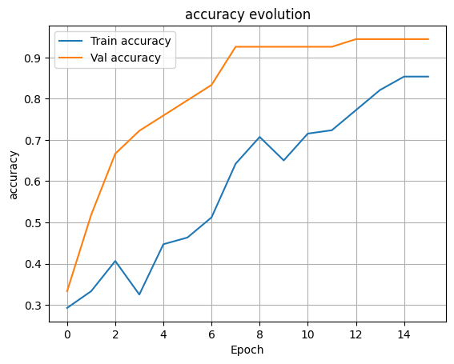

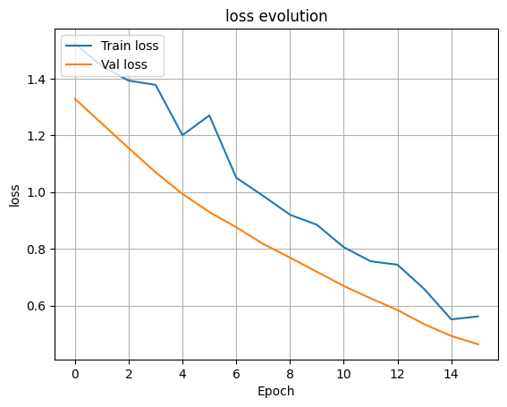

```
2/2 ━━━━━━━━━━━━━━━━━━━━ 6s 2s/step
```

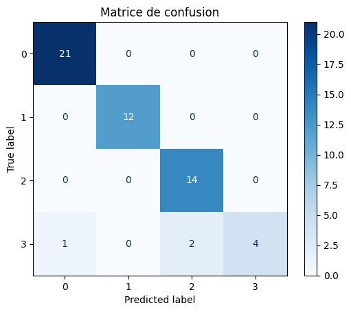

```
Classification report:
              precision    recall  f1-score   support

           0       0.95      1.00      0.98        21
           1       1.00      1.00      1.00        12
           2       0.88      1.00      0.93        14
           3       1.00      0.57      0.73         7

    accuracy                           0.94        54
   macro avg       0.96      0.89      0.91        54
weighted avg       0.95      0.94      0.94        54

Temps d'entraînement : 243.76 secondes
```

```python
from tensorflow.keras.layers import Input, Flatten
from tensorflow.keras.models import Model
from TP3_utils import MLP_transfer

lr=1e-4
batch_size=16
epochs=16
ad=Adam(learning_rate=lr)

# Transfer learning
input_tensor = Input(shape=(224,224,3))
VGG = tf.keras.applications.VGG16(
    weights='imagenet',
    include_top=False,
    input_tensor=input_tensor
)
for layer in VGG.layers:
    layer.trainable = False

x = VGG.output
x = Flatten()(x)
x = MLP_transfer(x, num_classes)
model_transfer = Model(inputs=VGG.input, outputs=x)

model_transfer.summary()

model_transfer.compile(
    loss='categorical_crossentropy',
    optimizer=Adam(1e-5),
    metrics=['accuracy']
)

tps1 = time.time()
history =model_transfer.fit(
    X_train,
    Y_train,
    batch_size=batch_size,
    epochs=epochs,
    verbose=1,
    validation_data=(X_test, Y_test)
#     callbacks=[earlStopBis, lr_schedulerBis],
)
tps2 = time.time()

loss, accuracy = model_transfer.evaluate(X_test, Y_test)
print(f'Test loss: {loss}, Test accuracy: {accuracy}')

affiche(history)
preds = model_transfer.predict(X_test)
eval_classif(Y_test, preds)
print("Temps d'entraînement : {:.2f} secondes".format(tps2 - tps1))
```

On obtiens très facilement des performances nettement meilleures qu'avant:

```
Classification report:
              precision    recall  f1-score   support

           0       0.95      1.00      0.98        21
           1       1.00      1.00      1.00        12
           2       0.88      1.00      0.93        14
           3       1.00      0.57      0.73         7

    accuracy                           0.94        54
   macro avg       0.96      0.89      0.91        54
weighted avg       0.95      0.94      0.94        54

Temps d'entraînement : 243.76 secondes
```

```
8/8 ━━━━━━━━━━━━━━━━━━━━ 18s 2s/step - accuracy: 0.9024 - loss: 0.5267 - val_accuracy: 0.9444 - val_loss: 0.4488
8/8 ━━━━━━━━━━━━━━━━━━━━ 17s 2s/step - accuracy: 0.8211 - loss: 0.5406 - val_accuracy: 0.9444 - val_loss: 0.4355
8/8 ━━━━━━━━━━━━━━━━━━━━ 17s 2s/step - accuracy: 0.8537 - loss: 0.5206 - val_accuracy: 0.9630 - val_loss: 0.4219
8/8 ━━━━━━━━━━━━━━━━━━━━ 17s 2s/step - accuracy: 0.8374 - loss: 0.4791 - val_accuracy: 0.9630 - val_loss: 0.4101
8/8 ━━━━━━━━━━━━━━━━━━━━ 16s 2s/step - accuracy: 0.8455 - loss: 0.4632 - val_accuracy: 0.9630 - val_loss: 0.3985
8/8 ━━━━━━━━━━━━━━━━━━━━ 17s 2s/step - accuracy: 0.8618 - loss: 0.4910 - val_accuracy: 0.9630 - val_loss: 0.3869
8/8 ━━━━━━━━━━━━━━━━━━━━ 17s 2s/step - accuracy: 0.8455 - loss: 0.5002 - val_accuracy: 0.9630 - val_loss: 0.3766
8/8 ━━━━━━━━━━━━━━━━━━━━ 16s 2s/step - accuracy: 0.8618 - loss: 0.5068 - val_accuracy: 0.9630 - val_loss: 0.3664
8/8 ━━━━━━━━━━━━━━━━━━━━ 16s 2s/step - accuracy: 0.8862 - loss: 0.4306 - val_accuracy: 0.9630 - val_loss: 0.3564
8/8 ━━━━━━━━━━━━━━━━━━━━ 16s 2s/step - accuracy: 0.9024 - loss: 0.4419 - val_accuracy: 0.9630 - val_loss: 0.3469
8/8 ━━━━━━━━━━━━━━━━━━━━ 16s 2s/step - accuracy: 0.9268 - loss: 0.3978 - val_accuracy: 0.9630 - val_loss: 0.3379
8/8 ━━━━━━━━━━━━━━━━━━━━ 16s 2s/step - accuracy: 0.9024 - loss: 0.4133 - val_accuracy: 0.9630 - val_loss: 0.3296
8/8 ━━━━━━━━━━━━━━━━━━━━ 16s 2s/step - accuracy: 0.8943 - loss: 0.3938 - val_accuracy: 0.9630 - val_loss: 0.3215
8/8 ━━━━━━━━━━━━━━━━━━━━ 16s 2s/step - accuracy: 0.9268 - loss: 0.3630 - val_accuracy: 0.9630 - val_loss: 0.3129
8/8 ━━━━━━━━━━━━━━━━━━━━ 16s 2s/step - accuracy: 0.9350 - loss: 0.3297 - val_accuracy: 0.9630 - val_loss: 0.3046
8/8 ━━━━━━━━━━━━━━━━━━━━ 16s 2s/step - accuracy: 0.8618 - loss: 0.4339 - val_accuracy: 0.9630 - val_loss: 0.2968
2/2 ━━━━━━━━━━━━━━━━━━━━ 5s 2s/step - accuracy: 0.9630 - loss: 0.2968
Test loss: 0.29680973291397095, Test accuracy: 0.9629629850387573
```

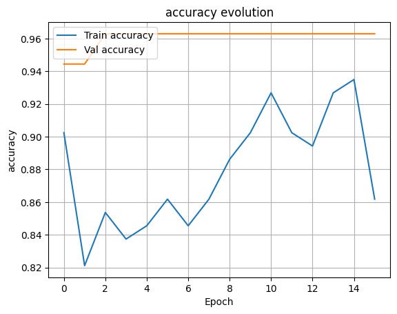

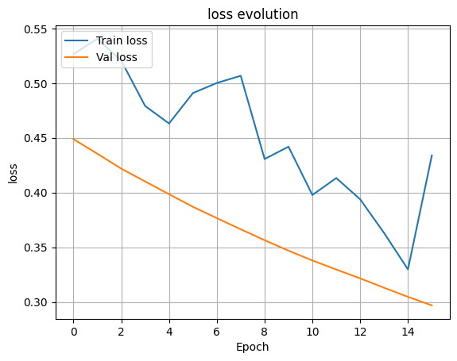

[output not shown]

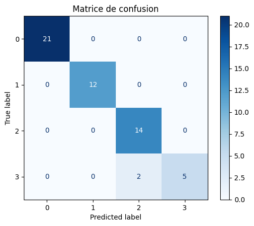

```
Classification report:
              precision    recall  f1-score   support

           0       1.00      1.00      1.00        21
           1       1.00      1.00      1.00        12
           2       0.88      1.00      0.93        14
           3       1.00      0.71      0.83         7

    accuracy                           0.96        54
   macro avg       0.97      0.93      0.94        54
weighted avg       0.97      0.96      0.96        54

Temps d'entraînement : 264.70 secondes
```

```python
################## Fine-tuning #################

for layer in VGG.layers[-4:]:
    layer.trainable = True

model_transfer.compile(
    loss='categorical_crossentropy',
    optimizer=Adam(1e-6),
    metrics=['accuracy']
)

tps1 = time.time()
history =model_transfer.fit(
    X_train,
    Y_train,
    batch_size=batch_size,
    epochs=epochs,
    verbose=1,
    validation_data=(X_test, Y_test)
#     callbacks=[earlStopBis, lr_schedulerBis],
)
tps2 = time.time()

loss, accuracy = model_transfer.evaluate(X_test, Y_test)
print(f'Test loss: {loss}, Test accuracy: {accuracy}')

affiche(history)
preds = model_transfer.predict(X_test)
eval_classif(Y_test, preds)
print("Temps d'entraînement : {:.2f} secondes".format(tps2 - tps1))
```

Avec du fine-tuning les performances sont encore améliorées:

```
Classification report:
              precision    recall  f1-score   support

           0       1.00      1.00      1.00        21
           1       1.00      1.00      1.00        12
           2       0.88      1.00      0.93        14
           3       1.00      0.71      0.83         7

    accuracy                           0.96        54
   macro avg       0.97      0.93      0.94        54
weighted avg       0.97      0.96      0.96        54

Temps d'entraînement : 264.70 secondes
```

Pour éviter de ruiner les poids appris par VGG, j'ai changé la façon dont je permettais aux couches d'être fine-tuned pour ne laisser que les 4 dernieres couches (celles-ci étant les plus spécialisées).  
On note aussi que la précision elle même a eu l'air de stagner, car ce fine-tuning n'a corrigé qu'une des 3 erreurs que faisais le modèle auparavant. Cependant, la loss à bel et bien progressé signifiant sûrement une hausse de la certitude.

```
(60000, 28, 28, 1) (60000, 28, 28, 1)
0.0 1.0
0.0 1.0
```

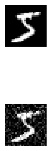

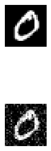

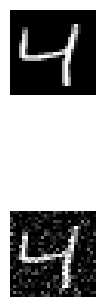

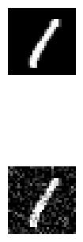

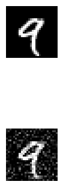

```python
from TP3_utils import load_mnist_with_noise
(X_train, Y_train, X_train_noise), (X_test, Y_test, X_test_noise) = load_mnist_with_noise()

print(X_train_noise.shape, X_train.shape)
print(X_train_noise.min(), X_train_noise.max())
print(X_train.min(), X_train.max())

# Display the train data and a version of it with added noise
for i in range(5):
    plt.subplot(2,5,i+1)
    plt.imshow(X_train[i,:].reshape([28,28]), cmap='gray')
    plt.axis('off')
    plt.subplot(2,5,i+6)
    plt.imshow(X_train_noise[i,:].reshape([28,28]), cmap='gray')
    plt.axis('off')
    plt.show()
```

```
Model: "functional_32"
```

```
┏━━━━━━━━━━━━━━━━━━━━━━━━━━━━━━━━━┳━━━━━━━━━━━━━━━━━━━━━━━━┳━━━━━━━━━━━━━━━┓
┃ Layer (type)                    ┃ Output Shape           ┃       Param # ┃
┡━━━━━━━━━━━━━━━━━━━━━━━━━━━━━━━━━╇━━━━━━━━━━━━━━━━━━━━━━━━╇━━━━━━━━━━━━━━━┩
│ input_layer_44 (InputLayer)     │ (None, 28, 28, 1)      │             0 │
├─────────────────────────────────┼────────────────────────┼───────────────┤
│ conv2d_98 (Conv2D)              │ (None, 28, 28, 16)     │           160 │
├─────────────────────────────────┼────────────────────────┼───────────────┤
│ max_pooling2d_48 (MaxPooling2D) │ (None, 14, 14, 16)     │             0 │
├─────────────────────────────────┼────────────────────────┼───────────────┤
│ conv2d_99 (Conv2D)              │ (None, 14, 14, 32)     │         4,640 │
├─────────────────────────────────┼────────────────────────┼───────────────┤
│ max_pooling2d_49 (MaxPooling2D) │ (None, 7, 7, 32)       │             0 │
├─────────────────────────────────┼────────────────────────┼───────────────┤
│ conv2d_100 (Conv2D)             │ (None, 7, 7, 64)       │        18,496 │
├─────────────────────────────────┼────────────────────────┼───────────────┤
│ conv2d_transpose_46             │ (None, 14, 14, 32)     │        18,464 │
│ (Conv2DTranspose)               │                        │               │
├─────────────────────────────────┼────────────────────────┼───────────────┤
│ conv2d_transpose_47             │ (None, 28, 28, 16)     │         4,624 │
│ (Conv2DTranspose)               │                        │               │
├─────────────────────────────────┼────────────────────────┼───────────────┤
│ conv2d_101 (Conv2D)             │ (None, 28, 28, 1)      │           145 │
└─────────────────────────────────┴────────────────────────┴───────────────┘
```

```
 Total params: 46,529 (181.75 KB)
```

```
 Trainable params: 46,529 (181.75 KB)
```

```
 Non-trainable params: 0 (0.00 B)
```

```
235/235 ━━━━━━━━━━━━━━━━━━━━ 12s 46ms/step - loss: 0.0241 - val_loss: 0.0157 - learning_rate: 0.0010
235/235 ━━━━━━━━━━━━━━━━━━━━ 10s 44ms/step - loss: 0.0069 - val_loss: 0.0143 - learning_rate: 0.0010
235/235 ━━━━━━━━━━━━━━━━━━━━ 10s 44ms/step - loss: 0.0058 - val_loss: 0.0136 - learning_rate: 0.0010
235/235 ━━━━━━━━━━━━━━━━━━━━ 11s 45ms/step - loss: 0.0053 - val_loss: 0.0132 - learning_rate: 0.0010
235/235 ━━━━━━━━━━━━━━━━━━━━ 10s 44ms/step - loss: 0.0049 - val_loss: 0.0130 - learning_rate: 0.0010
235/235 ━━━━━━━━━━━━━━━━━━━━ 10s 44ms/step - loss: 0.0047 - val_loss: 0.0130 - learning_rate: 0.0010
235/235 ━━━━━━━━━━━━━━━━━━━━ 0s 42ms/step - loss: 0.0045
Epoch 7: ReduceLROnPlateau reducing learning rate to 0.0007500000356230885.
235/235 ━━━━━━━━━━━━━━━━━━━━ 10s 44ms/step - loss: 0.0045 - val_loss: 0.0129 - learning_rate: 0.0010
235/235 ━━━━━━━━━━━━━━━━━━━━ 10s 44ms/step - loss: 0.0043 - val_loss: 0.0129 - learning_rate: 7.5000e-04
Restoring model weights from the end of the best epoch: 5.
313/313 ━━━━━━━━━━━━━━━━━━━━ 1s 2ms/step
```

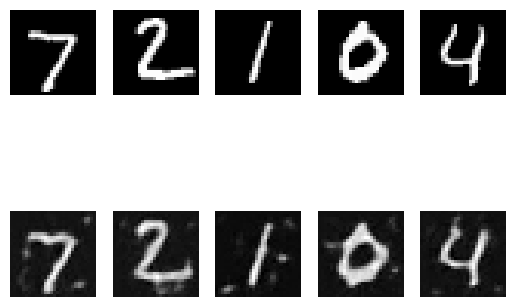

[figure not shown]

[figure not shown]

```
313/313 ━━━━━━━━━━━━━━━━━━━━ 1s 2ms/step - loss: 0.0130
Test loss: 0.0130
313/313 ━━━━━━━━━━━━━━━━━━━━ 1s 2ms/step
```

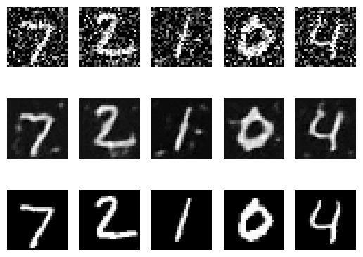

```
Temps d'entraînement : 264.70 secondes
```

```python
from TP3_utils import build_autoencoder


lr_scheduler = ReduceLROnPlateau(monitor='val_loss', factor=0.75, patience=2, min_lr=1e-6, verbose=1)
earlStop = EarlyStopping(monitor='val_loss', min_delta=1e-4, patience=5, restore_best_weights=True, verbose = 1)


autoencoder = build_autoencoder(X_train[0].shape)
autoencoder.summary()


autoencoder.compile(optimizer=Adam(1e-3), loss='mse')

history_ae = autoencoder.fit(
    X_train_noise,
    X_train,
    validation_data=(X_test_noise, X_test),
    epochs=8,
    batch_size=256,
    callbacks=[earlStop, lr_scheduler]
)


# Visualisation reconstruction
decoded_imgs = autoencoder.predict(X_test_noise)
for i in range(5):
    plt.subplot(2,5,i+1)
    plt.imshow(X_test[i].reshape(28,28), cmap='gray')
    plt.axis('off')
    plt.subplot(2,5,i+6)
    plt.imshow(decoded_imgs[i].reshape(28,28), cmap='gray')
    plt.axis('off')
plt.show()


affiche(history)
test_loss = autoencoder.evaluate(X_test_noise, X_test)
print(f'Test loss: {test_loss:.4f}')


decoded_imgs = autoencoder.predict(X_test_noise)

for i in range(5):
    plt.subplot(3,5,i+1)
    plt.imshow(X_test_noise[i].reshape(28,28), cmap='gray')
    plt.axis('off')
    if i == 0: plt.ylabel('Bruitée')

    plt.subplot(3,5,i+6)
    plt.imshow(decoded_imgs[i].reshape(28,28), cmap='gray')
    plt.axis('off')
    if i == 0: plt.ylabel('Reconstruite')

    plt.subplot(3,5,i+11)
    plt.imshow(X_test[i].reshape(28,28), cmap='gray')
    plt.axis('off')
    if i == 0: plt.ylabel('Originale')
plt.show()

print("Temps d'entraînement : {:.2f} secondes".format(tps2 - tps1))
```

```python
from TP3_utils import build_vae
lr_scheduler = ReduceLROnPlateau(monitor='val_loss', factor=0.8, patience=2, min_lr=1e-6, verbose=1)
earlStop = EarlyStopping(monitor='val_loss', min_delta=1e-4, patience=5, restore_best_weights=True, verbose = 1)

latent_dim = 2
coeff = 0.01
vae, encoder, decoder = build_vae(latent_dim=latent_dim, coeff=coeff)
vae.compile(optimizer=Adam(1e-3), loss='mse')

history = vae.fit(
    X_train_noise, X_train,
    validation_data=(X_test_noise, X_test),
    epochs=20,
    batch_size=128,
    callbacks=[earlStop, lr_scheduler]
)
```

[output not shown]

```
313/313 ━━━━━━━━━━━━━━━━━━━━ 1s 3ms/step
```

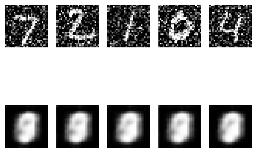

```python
decoded_imgs = vae.predict(X_test_noise)
for i in range(5):
    plt.subplot(2,5,i+1)
    plt.imshow(X_test_noise[i].reshape(28,28), cmap='gray')
    plt.axis('off')
    if i==0: plt.ylabel('Bruitée')

    plt.subplot(2,5,i+6)
    plt.imshow(decoded_imgs[i].reshape(28,28), cmap='gray')
    plt.axis('off')
    if i==0: plt.ylabel('Reconstruite')
plt.show()
```

[output not shown]

[output cut: 45 more lines]

[output not shown]

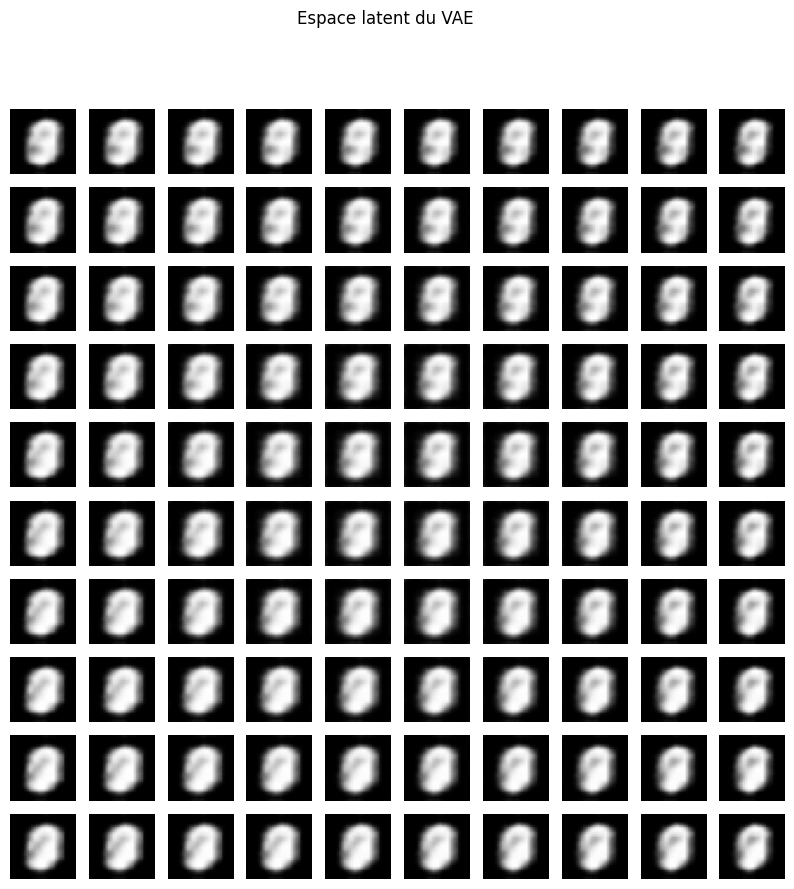

```python
n = 10
grid_x = np.linspace(-3, 3, n)
grid_y = np.linspace(-3, 3, n)

plt.figure(figsize=(10,10))
for i, xi in enumerate(grid_x):
    for j, yi in enumerate(grid_y):
        z_sample = np.array([[xi, yi]])
        x_decoded = decoder.predict(z_sample)
        plt.subplot(n, n, i*n+j+1)
        plt.imshow(x_decoded[0].reshape(28,28), cmap='gray')
        plt.axis('off')
plt.suptitle("Espace latent du VAE")
plt.show()
```